# Data Handling: Import, Cleaning and Visualisation

Lecture 10:  
Exploratory Data Analysis and Visualization, Part II

Dr. Aurélien Sallin

2025-11-12

# Recap: Data cleaning and Data Visualization

## Use the five building block from `dplyr()`

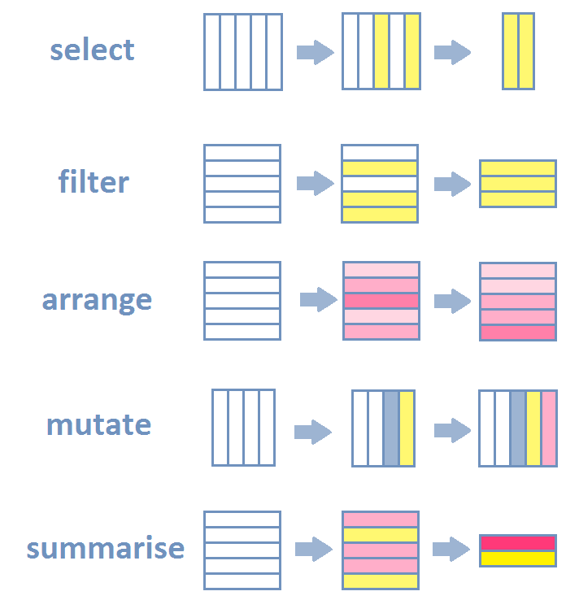

Source: [Intro to R for Social Scientists](https://jaspertjaden.github.io/course-intro2r/week3.html)

## Important additional tools

- `ifelse(test, yes, no)` returns a value with the same shape as the logical test. Filled with elements selected from either `yes` or `no` depending on whether the element of `test` is `TRUE` or `FALSE`

```r
df |>
  mutate(gender = ifelse(gender == "m", 1, 0))
```

- `case_when` vectorises multiple `ifelse()` statements. It is the `dplyr` equivalent of `if...else`

```r
df |>
  mutate(
    agegroup = case_when(
      age >= 0 & age < 19 ~ "0-18",
      age >= 19 & age < 66 ~ "19-65",
      age >= 66 & age < 100 ~ ">65",
      .default = "999"
    )
  )
```

- `stringr`: str_replace(), str_detect(), etc.
- `tolower` and `trimws`

## Exploratory data analysis

#### “To not mislead others and not embarrass yourself, know your data”.*

- Understand the **number of observations**, the **units**, the **quality** of data, the **definitions** of variables, what to do with **missing values**.

#### What type of variation occurs within my variables?

- **Typical values**: mean, mode, range, standard deviation.
- **Surprising values**: outliers, rare values, unusual patterns.

#### What type of covariation occurs between my variables?

- **Covariation** and **Patterns**.

## Missing Values

1. Keep in mind the **source of missingness throughout your analysis**
2. Be aware of the **trade-off between data loss and bias**
3. **Choose imputation methods wisely** (or, maybe, don’t bother)

[figure not shown]

## Data visualization through tables and graphs

#### A **chart** typically contains at least one axis, the **values are represented in terms of visual objects** (dots, lines, bars) and axes typically have scales or labels.

- If we are interested in exploring, analyzing or communicating **patterns** in the data, charts are more useful than tables.

#### A **table** typically contains rows and columns, and the **values are represented by text**.

- If we are interested in exploring, analyzing or communicating **specific numbers** in the data, tables are more useful than graphs.

## The grammar of graphics

- The *`ggplot2`* package is an implementation of Leland Wilkinson’s ‘Grammar of Graphics’.
- `ggplot2` is so good that it has become *THE* reference [In python, use `plotnine` to apply the grammar of graphics.]

## Grammar of graphics with `ggplot2`

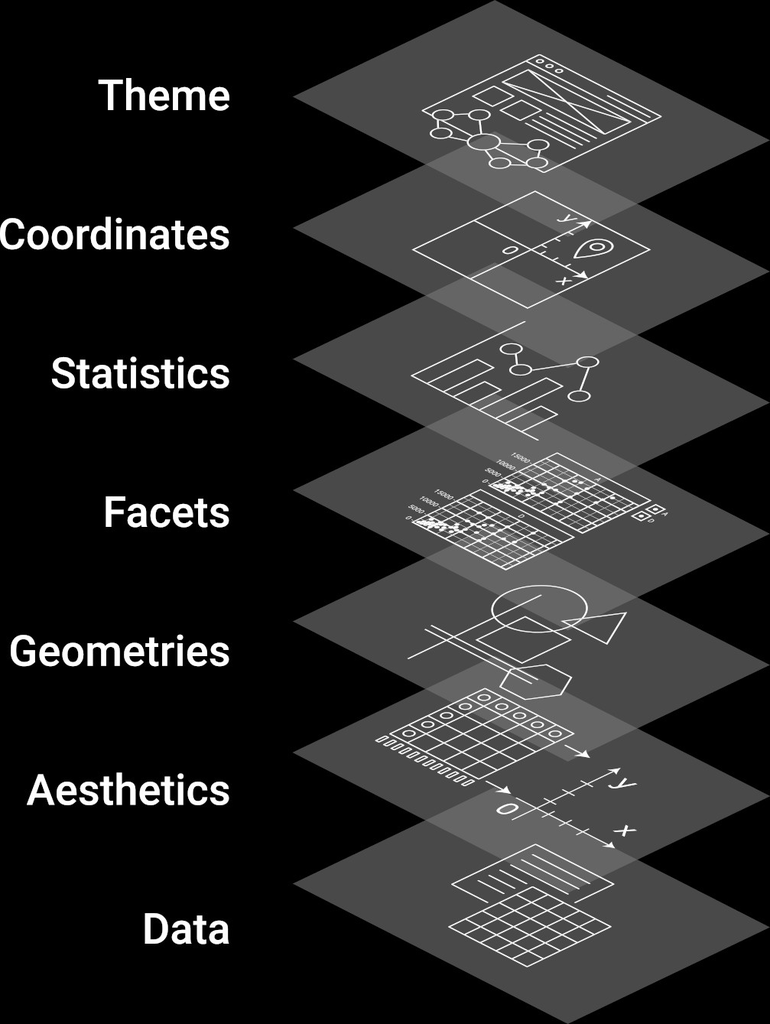

## The grammar of graphics in action

Example from [A Comprehensive Guide to the Grammar of Graphics for Effective Visualization of Multi-dimensional Data](https://towardsdatascience.com/a-comprehensive-guide-to-the-grammar-of-graphics-for-effective-visualization-of-multi-dimensional-1f92b4ed4149) using the built-in `mtcars` dataset in R.

```r
mtcars # mtcars is a built-in dataset in R
```

```
                     mpg cyl  disp  hp drat    wt  qsec vs am gear carb
Mazda RX4           21.0   6 160.0 110 3.90 2.620 16.46  0  1    4    4
Mazda RX4 Wag       21.0   6 160.0 110 3.90 2.875 17.02  0  1    4    4
Datsun 710          22.8   4 108.0  93 3.85 2.320 18.61  1  1    4    1
Hornet 4 Drive      21.4   6 258.0 110 3.08 3.215 19.44  1  0    3    1
Hornet Sportabout   18.7   8 360.0 175 3.15 3.440 17.02  0  0    3    2
Valiant             18.1   6 225.0 105 2.76 3.460 20.22  1  0    3    1
Duster 360          14.3   8 360.0 245 3.21 3.570 15.84  0  0    3    4
Merc 240D           24.4   4 146.7  62 3.69 3.190 20.00  1  0    4    2
Merc 230            22.8   4 140.8  95 3.92 3.150 22.90  1  0    4    2
Merc 280            19.2   6 167.6 123 3.92 3.440 18.30  1  0    4    4
Merc 280C           17.8   6 167.6 123 3.92 3.440 18.90  1  0    4    4
Merc 450SE          16.4   8 275.8 180 3.07 4.070 17.40  0  0    3    3
Merc 450SL          17.3   8 275.8 180 3.07 3.730 17.60  0  0    3    3
Merc 450SLC         15.2   8 275.8 180 3.07 3.780 18.00  0  0    3    3
Cadillac Fleetwood  10.4   8 472.0 205 2.93 5.250 17.98  0  0    3    4
Lincoln Continental 10.4   8 460.0 215 3.00 5.424 17.82  0  0    3    4
Chrysler Imperial   14.7   8 440.0 230 3.23 5.345 17.42  0  0    3    4
Fiat 128            32.4   4  78.7  66 4.08 2.200 19.47  1  1    4    1
Honda Civic         30.4   4  75.7  52 4.93 1.615 18.52  1  1    4    2
Toyota Corolla      33.9   4  71.1  65 4.22 1.835 19.90  1  1    4    1
Toyota Corona       21.5   4 120.1  97 3.70 2.465 20.01  1  0    3    1
Dodge Challenger    15.5   8 318.0 150 2.76 3.520 16.87  0  0    3    2
AMC Javelin         15.2   8 304.0 150 3.15 3.435 17.30  0  0    3    2
Camaro Z28          13.3   8 350.0 245 3.73 3.840 15.41  0  0    3    4
Pontiac Firebird    19.2   8 400.0 175 3.08 3.845 17.05  0  0    3    2
Fiat X1-9           27.3   4  79.0  66 4.08 1.935 18.90  1  1    4    1
Porsche 914-2       26.0   4 120.3  91 4.43 2.140 16.70  0  1    5    2
Lotus Europa        30.4   4  95.1 113 3.77 1.513 16.90  1  1    5    2
Ford Pantera L      15.8   8 351.0 264 4.22 3.170 14.50  0  1    5    4
Ferrari Dino        19.7   6 145.0 175 3.62 2.770 15.50  0  1    5    6
Maserati Bora       15.0   8 301.0 335 3.54 3.570 14.60  0  1    5    8
Volvo 142E          21.4   4 121.0 109 4.11 2.780 18.60  1  1    4    2
```

## From two dimensions…

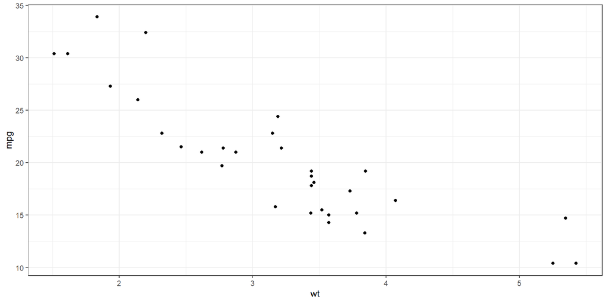

```r
ggplot(mtcars, aes(x = wt, y = mpg)) +
  geom_point() +
  theme_bw()
```

## To three dimensions…

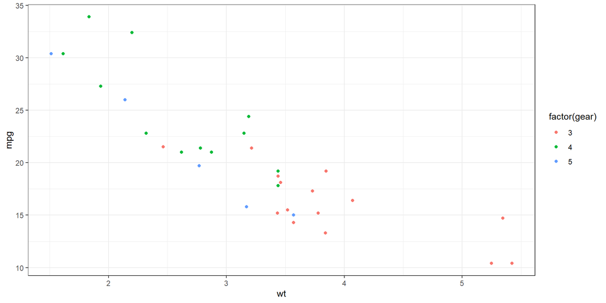

```r
ggplot(mtcars, aes(x = wt, y = mpg, color=factor(gear))) +
  geom_point() +
  theme_bw()
```

## To four dimensions…

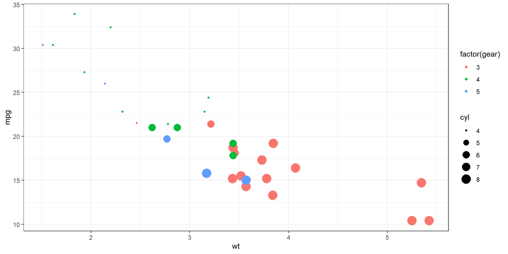

```r
ggplot(mtcars, aes(x = wt, y = mpg, color=factor(gear), size = cyl)) +
  geom_point() +
  theme_bw()
```

## To five dimensions

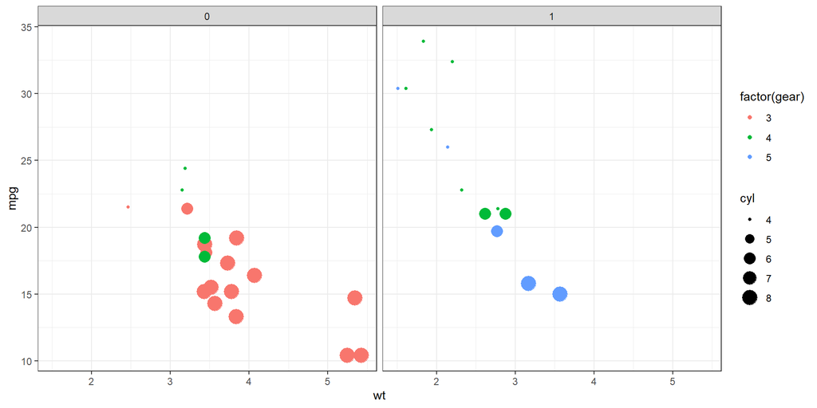

```r
ggplot(mtcars, aes(x = wt, y = mpg, color=factor(gear), size = cyl)) +
  geom_point() +
  facet_wrap(~am) +
  theme_bw()
```

## To six dimensions

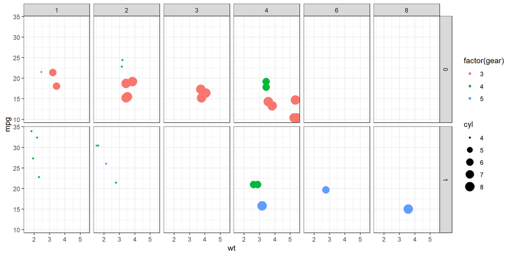

```r
ggplot(mtcars, aes(x = wt, y = mpg, color=factor(gear), size = cyl)) +
  geom_point() +
  facet_grid(am ~ carb) +
  theme_bw()
```

## Quiz on `geom_line()` vs `geom_smooth()`

```r
ggplot(mtcars, aes(x = wt, y = mpg)) +
  geom_point() +
  geom_line() +
  theme_bw()
```

```r
ggplot(mtcars, aes(x = wt, y = mpg)) +
  geom_point() +
  geom_smooth(method = "lm", se = FALSE) +
  theme_bw()
```

## Quiz on `geom_line()` vs `geom_smooth()`

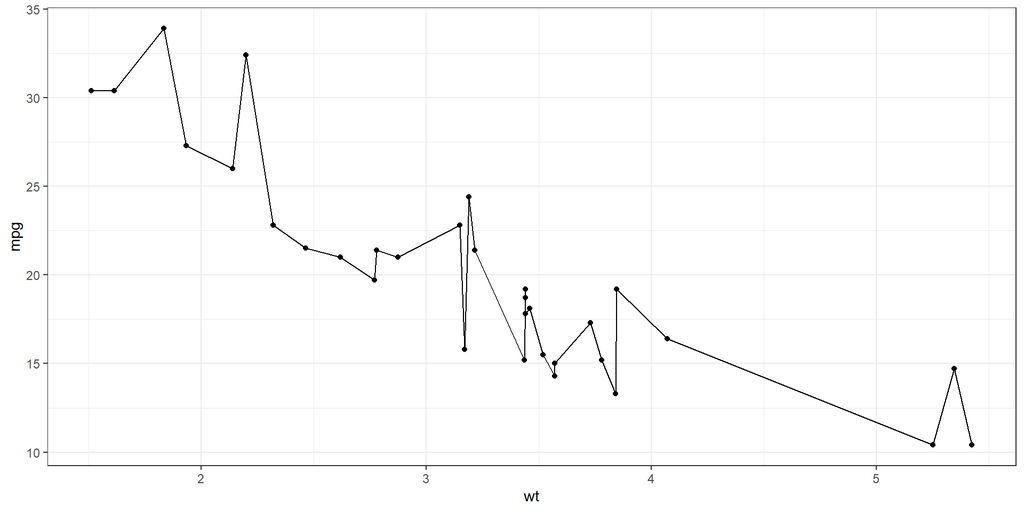

```r
ggplot(mtcars, aes(x = wt, y = mpg)) +
  geom_point() +
  geom_line() +
  theme_bw()
```

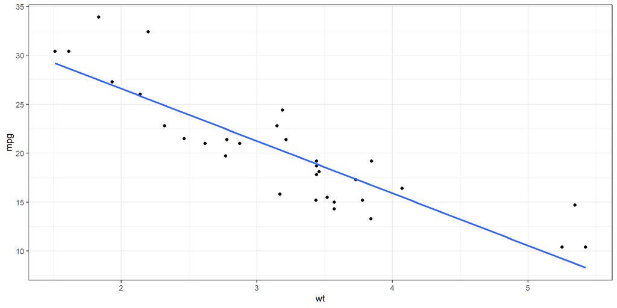

```r
ggplot(mtcars, aes(x = wt, y = mpg)) +
  geom_point() +
  geom_smooth(method = "lm", se = FALSE) +
  theme_bw()
```

## Quiz on size, fill, color arguments

```r
mtcars |>
  ggplot(aes(x = wt, y = mpg)) +
  geom_point(color = "blue") +
  theme_bw()
```

```r
mtcars |>
  ggplot(aes(x = wt, y = mpg, color=factor(gear))) +
  geom_point() +
  theme_bw()
```

## Quiz on size, fill, color arguments

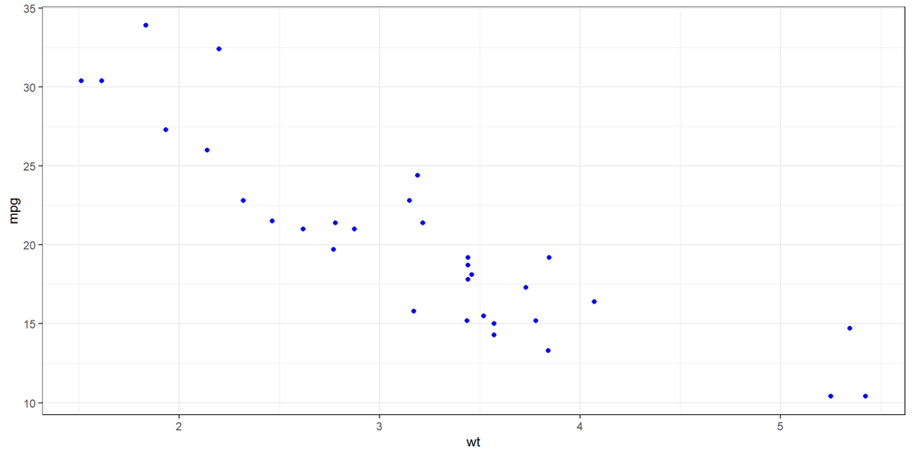

```r
mtcars |>
  ggplot(aes(x = wt, y = mpg)) +
  geom_point(color = "blue") +
  theme_bw()
```

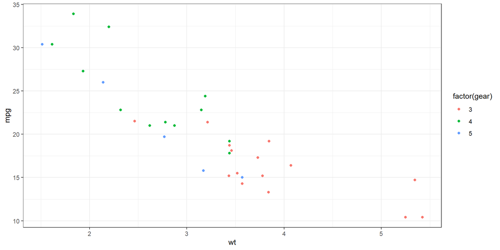

```r
mtcars |>
  ggplot(aes(x = wt, y = mpg, color=factor(gear))) +
  geom_point() +
  theme_bw()
```

## Quiz on `geom_bar()`

Which code produced the figure? (This question would not be an exam question, as it requires specific knowledge of `geom_bar()`. Solve it with R.)

```r
got_data <- tibble(
  house = c("Stark", "Stark", "Stark", "Lannister", "Lannister", "Lannister",
            "Targaryen", "Targaryen", "Targaryen"),
  soldiers = c(5000, 3000, 500, 4000, 3800, 1900, 4200, 3500, 5000),
  year = c(1,2,3,1,2,3,1,2,3)
)
```

```r
ggplot(got_data, aes(x = year, y = soldiers, fill = house)) +
  geom_bar(stat = "identity") +
  theme_classic()
```

```r
ggplot(got_data, aes(x = year, y = soldiers, fill = house)) +
  geom_histogram() +
  theme_classic()
```

[figure not shown]

```r
ggplot(got_data, aes(x = year, fill = house)) +
  geom_bar() +
  theme_classic()
```

# Today

## Goals for today

#### Building on what we covered last week:

1. Know how to conduct exploratory data analysis (EDA).
2. Visualize data using tables.
3. Visualize data using the grammar of graphics.
4. Produce effective data visualization.

# From graphs to effective data visualization

## Data visualization: some principles

- Values are represented by their **position relative to the axes**: line charts and scatterplots.
- Values are represented by the **size of an area**: bar charts and area charts.
- Values are **continuous**: use chart type that visually connects elements (line chart).
- Values are **categorical**: use chart type that visually separates elements (bar chart).

(Source: [Data Visualization Basics for Economists](https://hhsievertsen.github.io/EconDataBook/data-visualization-basics.html))

“Greatest number of ideas in the shortest time with the least ink in the smallest space” (Edward Tufte, 1983)

## Data visualization: some principles

Recommendations from Edward Tufte’s “The Visual Display of Quantitative Information” (1983)

1. Lie Factor
2. Data-to-ink Ratio
3. Data density

[figure not shown]

## Lie Factor, or strive for graphical integrity

We can quantify the **Lie Factor** of a graph as a measure of how much the graphic distorts the data.

“The representation of numbers, as physically measured on the surface of the graphic itself, should be directly proportional to the quantities represented.” (Tufte, 1983)

Lie Factor = $\frac{\text{size of effect shown in graphic}}{\text{size of effect in data}}$

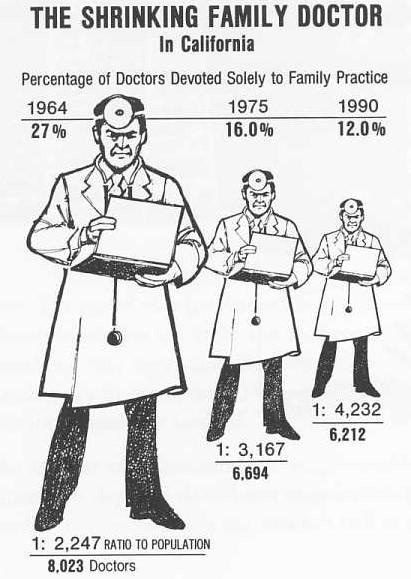

## Lie Factor, or strive for graphical integrity

Lie Factor = $\frac{\text{Yang had 39.1% of total ink}}{\text{Yang had 22.5%}}$ = 1.74

[figure not shown]

## Thou shalt not truncate the Y axis.

[figure not shown]

## Thou shalt not truncate the Y axis.

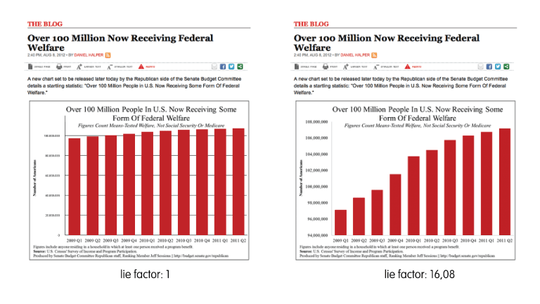

Source: [The lie factor and the baseline paradox](https://nightingaledvs.com/the-lie-factor-and-the-baseline-paradox/)

## Avoid pie charts

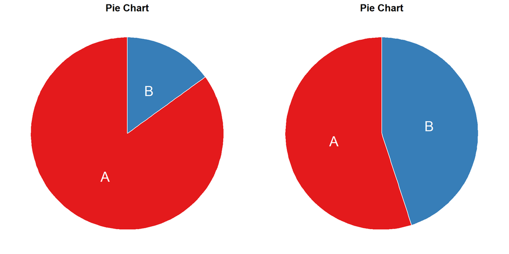

“All variations lead to overestimation of small values and underestimation of large ones.” [Kosara et al, 2018](https://diglib.eg.org/server/api/core/bitstreams/b0fc6407-96c8-4127-b1cb-6ca990b2ddb0/content)

## Avoid pie charts, please!

```r
# Libraries
library(tidyverse)
library(patchwork)

# create 3 data frame:
namesS <- c("Standard", "Health+", "Medicall", "GateKeeper", "Risk-")
data1 <- data.frame( name=factor(namesS, levels = namesS), value=c(17,18,20,22,24) )
data2 <- data.frame( name=factor(namesS, levels = namesS), value=c(20,18,21,20,20) )
data3 <- data.frame( name=factor(namesS, levels = namesS), value=c(24,23,21,19,18) )

# Plot
plot_pie <- function(data, vec){
ggplot(data, aes(x="name", y=value, fill=name)) +
  geom_bar(width = 1, stat = "identity") +
  coord_polar("y", start=0, direction = -1) +
  scale_fill_brewer(type = "div") +
  geom_text(aes(y = vec, label = rev(name), size=4, color=c( "white", rep("black", 4)))) +
  scale_color_manual(values=c("black", "white")) +
  theme_minimal() +
  theme(
    legend.position="none",
    plot.title = element_text(size=14),
    panel.grid = element_blank(),
    axis.text = element_blank(),
    legend.spacing=unit(0, "null")
  ) +
  xlab("") +
  ylab("")

}

# A function to make barplots
plot_bar <- function(data){
  ggplot(data, aes(x=name, y=value, fill=name)) +
    geom_bar( stat = "identity") +
    scale_fill_brewer(type = "div") +
    scale_color_manual(values=c("black", "white")) +
    theme_minimal() +
    theme(
      legend.position="none",
      plot.title = element_text(size=14),
      panel.grid = element_blank(),
    ) +
    ylim(0,25) +
    xlab("") +
    ylab("")
}
```

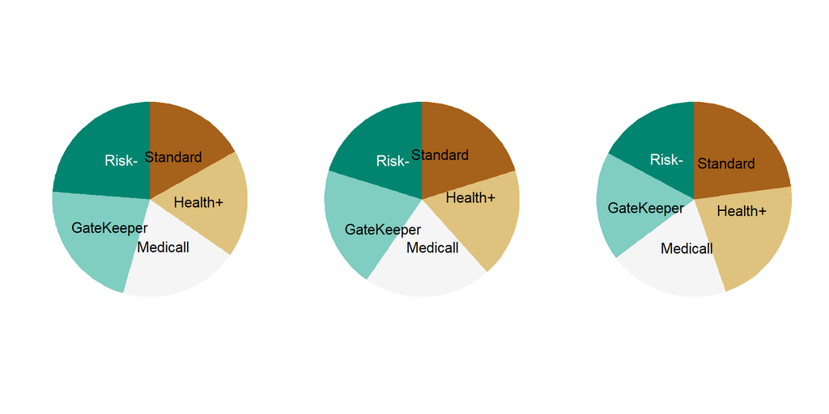

## Avoid pie charts, please!

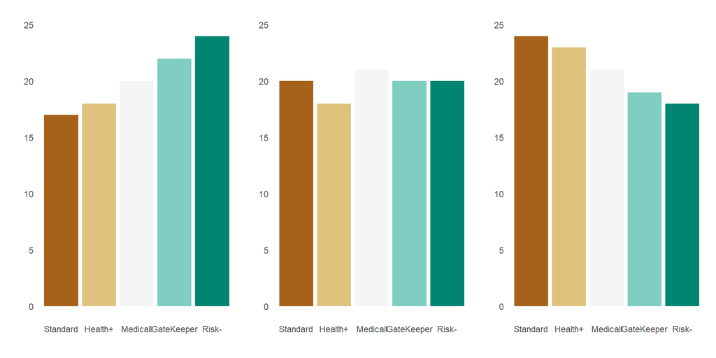

(Source: My own experience, [The Issue with Pie Charts](https://www.data-to-viz.com/caveat/pie.html))

## Different types of colors for different types of data

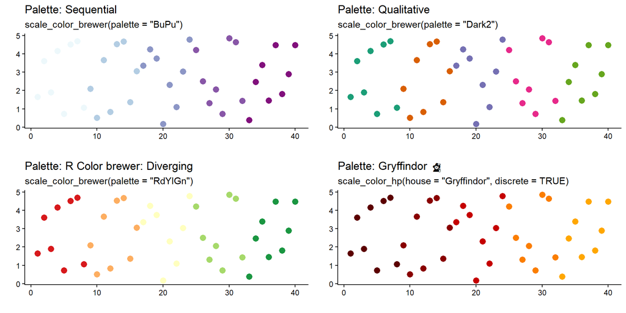

## Only what matters should be reported

- Data-ink Ratio = $\frac{\text{ink used for data points}}{\text{total ink used to print the graphic }}$
  - Proportion of a graphic’s ink devoted to the non-redundant display of data-information
  - **Data ink**: data points and measured quantities, such as the dots in a scatter plot
  - **Non-data ink**: functional marks such as titles, labels, axes, gridlines and tick points or decorative marks

#### Idea: maximize data-ink ratio

- Limits to this approach: we still need some ink to interpret and understand the data.
- No chart junk!

## Only what matters should be reported

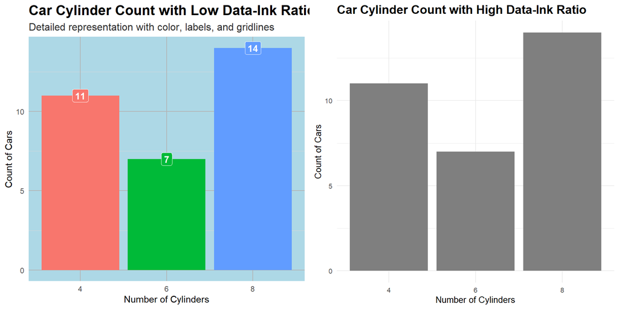

**Show code for the graphs**

```r
library(gridExtra)
library(ggthemes)

# High data-ink ratio graph (plot1)
plot1 <- mtcars |>
  group_by(cyl) |>
  count() |>
  ggplot(aes(x = as.factor(cyl), y = n, fill = as.factor(cyl), label = n)) +
  geom_bar(stat = "identity") +
  geom_label(color = "white", fontface = "bold", show.legend = FALSE) +
  labs(
    title = "Car Cylinder Count with Low Data-Ink Ratio",
    subtitle = "Detailed representation with color, labels, and gridlines",
    x = "Number of Cylinders",
    y = "Count of Cars"
  ) +
  theme_minimal() +
  theme(
    panel.background = element_rect(fill = "lightblue", color = NA),
    panel.grid.major = element_line(color = "gray70", size = 0.5),
    panel.grid.minor = element_line(color = "gray85", size = 0.25),
    legend.position = "none",
    plot.title = element_text(face = "bold", size = 16),
    plot.subtitle = element_text(size = 12, color = "gray20")
  )

# Minimalist graph (plot2)
plot2 <- mtcars |>
  group_by(cyl) |>
  count() |>
  ggplot(aes(x = as.factor(cyl), y = n)) +
  geom_bar(stat = "identity", fill = "gray50") +
  labs(
    title = "Car Cylinder Count with High Data-Ink Ratio",
    x = "Number of Cylinders",
    y = "Count of Cars"
  ) +
  theme_minimal() +
  theme(
    plot.title = element_text(face = "bold", size = 14),
    axis.title = element_text(size = 10),
    axis.text = element_text(size = 8)
  )

# Arrange both plots side by side
grid.arrange(plot1, plot2, ncol = 2)
```

## Only what matters should be reported

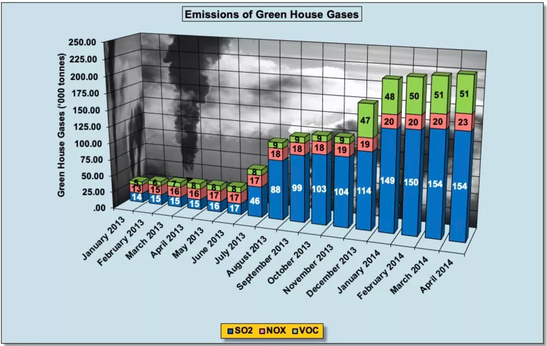

Source: [simplexct.com](https://simplexct.com/data-ink-ratio)

## Only what matters should be reported

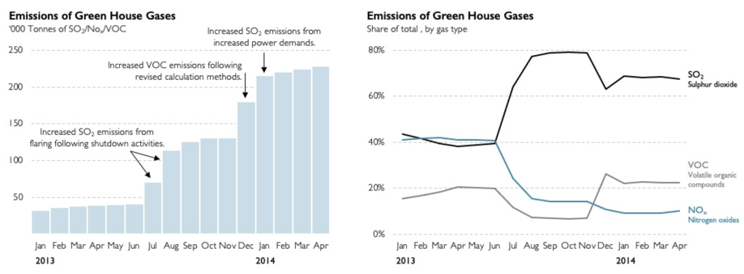

Source: [simplexct.com](https://simplexct.com/data-ink-ratio)

## Only what matters should be reported

Works for tables as well…

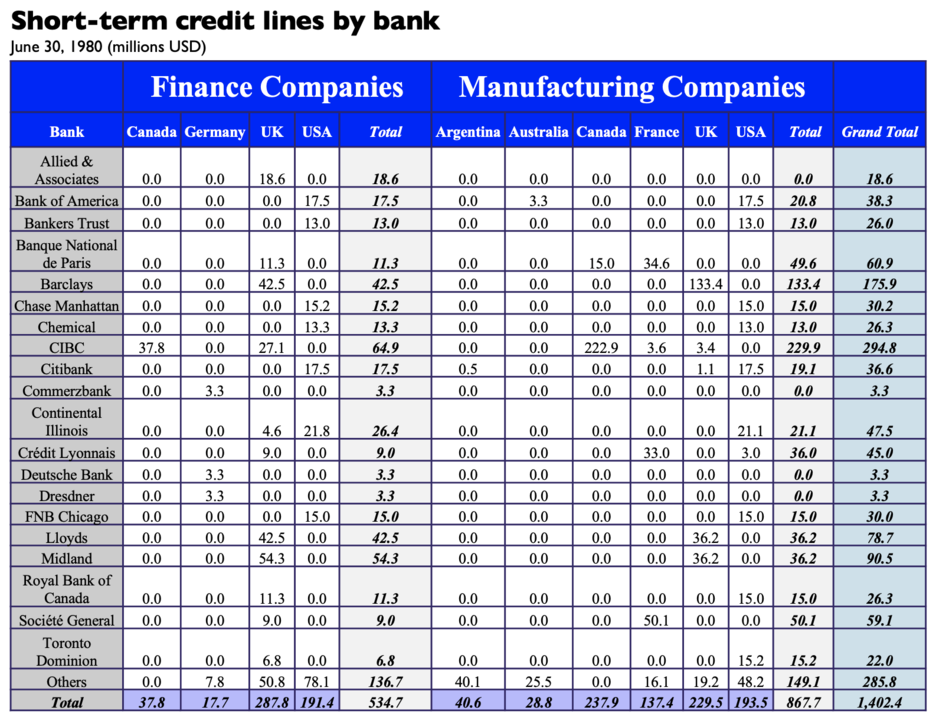

Source: [simplexct.com](https://simplexct.com/data-ink-ratio-tables)

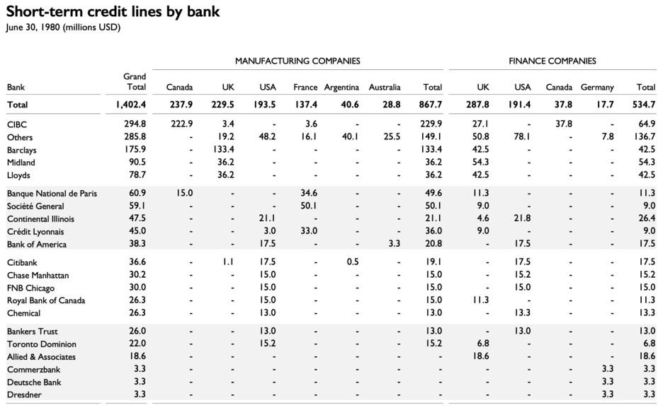

## Data density

The data density takes the number of data points that are being graphed relative to the physical size of the graphic to capture the principle of aiming to present many numbers in a small space:

- Data density = $\frac{\text{number of entries in data matrix}}{\text{area of data graphic}}$

## Data density

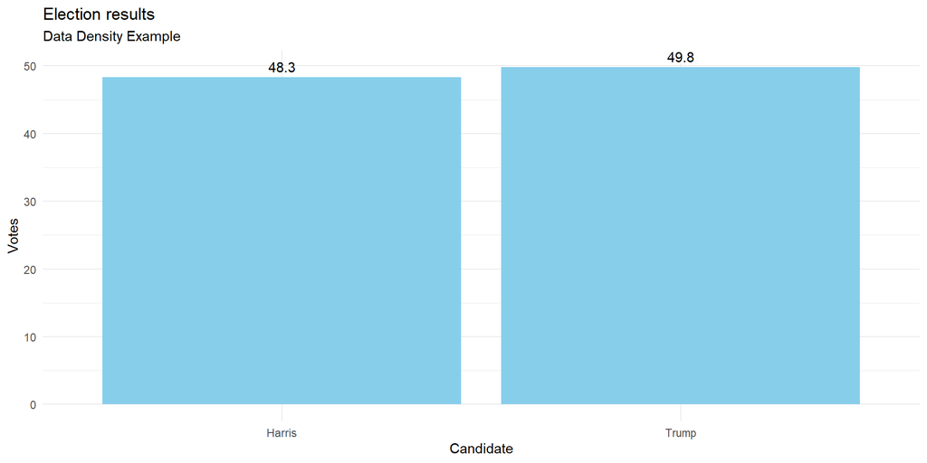

Election results

Data Density Example

| candidate | votes |
| --- | --- |
| Trump | 49.8 |
| Harris | 48.3 |

**49.8% voted for Trump, 48.3% for Harris.**

1. Graph
2. Table
3. Text

## Data visualization: from a graph to a story

#### Two pieces of advice I personally received:

1. If possible, **fit your whole story in one graph**.
2. Your audience should understand your graph **without the need of listening to you** or **reading your text.**
- Be simple and avoid unnecessary fanciness.
- Avoid pie charts and 3D charts.

## Have fun with ggplot

- Follow great dataviz leaders and influencers to learn how to master your craft: [data-to-viz (great!)](https://www.data-to-viz.com/#explore), [Yan Holtz](https://www.yan-holtz.com/), [Nicola Rennie](https://nrennie.rbind.io/), etc.
- Check [Tidytuesday](https://github.com/rfordatascience/tidytuesday), a weekly community of practice.

[figure not shown]

# A Design problem (self-study)

## A Design Problem

What is wrong with the graph below? Create your own version of the graph. If we have time, we will solve this example in class. If not, try to solve it on your own before you check the detailed solution below.

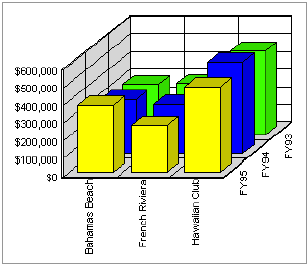

Source: [perceptual edge](https://perceptualedge.com/example3.php)

## A Design Problem

Use the following data to create your own version of the graph:

```r
dataChallenge <- data.frame(
  Location = rep(c("Bahamas Beach", "French Riviera", "Hawaiian Club"), each = 3),
  Fiscal_Year = rep(c("FY93", "FY94", "FY95"), times = 3),
  Revenue = c(
    250000, 275000, 350000,  # Bahamas Beach (FY93, FY94, FY95)
    260000, 200000, 210000,  # French Riviera (FY93, FY94, FY95)
    450000, 500000, 400000   # Hawaiian Club (FY93, FY94, FY95)
  )
)
```

## The problem with this graph

- The 3-D bars are impossible to read.
- The heavy grid lines offer nothing but distraction.
- The vertically-oriented labels (i.e., the resort names and years) are difficult to read.
- The years run from back to front, which is counter-intuitive.

## A first solution: comparative performance

[figure not shown]

```r
ggplot(dataChallenge, aes(x = Fiscal_Year, y = Revenue, fill = Location)) +
  geom_bar(stat = "identity", position = position_dodge()) +
  labs(
    title = "Resort Revenues by Location and Year",
    x = "Year",
    y = "Revenue (in USD)"
  ) +
  scale_y_continuous(labels = scales::dollar) +
  scale_x_discrete(labels = c("1993", "1994", "1995")) +
  theme_classic() +
  theme(legend.position = "bottom")
```

## A second solution: change of revenue over time

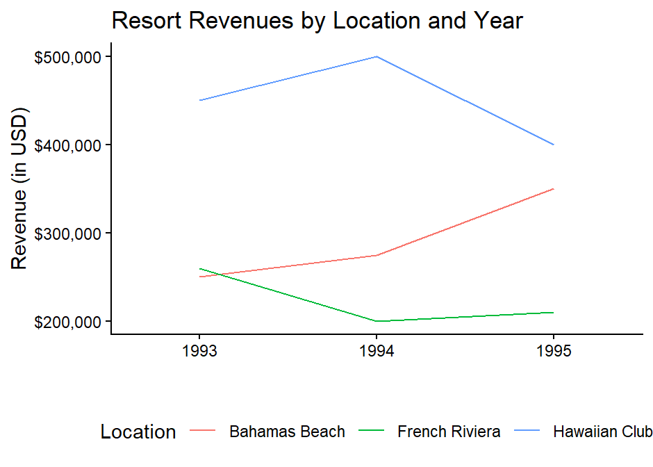

- This design makes it easy to see how revenue has changed from year to year at each of these resorts.
- However, the magnitudes are difficult to read because the y-axis does not start at 0!
- The eye is still going back and forth between the lines and the legend.

```r
ggplot(dataChallenge, aes(x = Fiscal_Year, y = Revenue, color = Location,
                          group = Location)) +
  geom_line() +
  labs(
    title = "Resort Revenues by Location and Year",
    x = "",
    y = "Revenue (in USD)"
  ) +
  scale_y_continuous(labels = scales::dollar) +
  scale_x_discrete(labels = c("1993", "1994", "1995"),
                   expand = expansion(add = c(0.5, 0.5))) +
  theme_classic() +
  theme(legend.position = "bottom")
```